# R을 이용한 서울시 지도 시각화 예제

서울시립대 통계학과 이용희

2019년 3월 7일

# 안내

이 화일은 창의주제 탐구세미나 1 에서 공간 통계와 시각화의 주제보고서를 작성하는 하는데 도움을 주기 위한 것이다. R에서 지도 객체를 입력하고 구별 통계 자료를 이용하여 지도 그림으로 시각화하는 과정을 알려주는 예제이다.

## 필요한 라이브러리

먼저 필요한 라이브러리(library)들을 실행시킨다. 만약에 필요한 라이브러리가 설치가 되어있지 않다면 `install.packages()` 명령을 통하여 먼저 실행한다. `install.packages()`는 최초 한번만 실행하면 라이브러리가 설치된다. 그 이후에 사용할 때마다 `library()` 명령을 통하여 불러오면 된다.

```r
library(sp)
library(rgdal)
library(RColorBrewer)
library(dplyr)
library(tidyr)
library(tmap)
library(knitr)
library(kableExtra)
```

## 지도자료 불러오기

서울의 구별 행정구역 지도화일을 `R`프로그램으로 불러와서 `R`에서 사용할 수 있도록 한다. 지도 자료는 지도 객체(map object)를 위한 특별한 형식인 `SpatialPolygonsDataFrame`으로 저장하는 되어있으며 학생들의 편의를 위하여 **Rdata** 형식의 화일에 저장되어 있다. 함수 `load`를 이용하여 R 데이터 화일 **seoulmap.RData**을 불러오면 지도 객체 `seoul0`을 이용할 수 있다.

서울의 구별 행정구역 지도 객체는 `SpatialPolygonsDataFrame` 형식으로 지정된 `seoul0`에 저장되어있다.

```r
load("seoulmap.RData")
seoul0
```

```
## class       : SpatialPolygonsDataFrame
## features    : 25
## extent      : 126.7699, 127.1709, 37.41528, 37.66492  (xmin, xmax, ymin, ymax)
## coord. ref. : +proj=longlat +datum=WGS84 +no_defs +ellps=WGS84 +towgs84=0,0,0
## variables   : 3
## names       :       code, engname,   name
## min values  : 1111000000,  Dobong, 강남구
## max values  : 1174000000, Yongsan, 중랑구
```

- 참고: MS-windows 에서는 다음과 같은 경고가 나올 수도 있으며 무시하면 된다.

`Warning messages: 1: In strsplit(x, "\n") : input string 1 is invalid in this locale`

## 지도자료 객체 `SpatialPolygonsDataFrame` 의 구조

지도 객체(map object) `seoul0`은 어떻게 구성되어 있는지 자료의 구성과 구조를 각각 `class` 과 `slotNames` 함수로 파악할 수 있다.

지도 객체(map object) `seoul0`은 `SpatialPolygonsDataFrame`이라는 클래스(class)로 정의되어 있으며 이는 `R`에서 지도 자료를 저장하는 기본적인 자료 형식이다.

```r
class(seoul0)
```

```
## [1] "SpatialPolygonsDataFrame"
## attr(,"package")
## [1] "sp"
```

또한 지도객체 `seoul0` 는 5개의 내부자료(slot 이라고 부른다)로 구성되어 있다. 이 내부자료는 함수 `slotNames`를 이용해서 어떤 이름으로 저장되어 있는지 알 수 있다. 내부자료 5개 중에서 `data`는 각 행정구역의 특성을 포함하는 데이터프레임(`dataframe`)이며 나머지 4개의 내부자료(`polygon`, `plotOrder`, `bbox`, `proj4string`)는 지도의 위치정보(점, 선, 경계 등)와 투영법(projection)에 대한 자료이다.

```r
slotNames(seoul0)
```

```
## [1] "data"        "polygons"    "plotOrder"   "bbox"        "proj4string"
```

지도 객체(map object) `seoul0`안에 포함된 실제 자료(data)는 `seoul0@data`에 저장되있으며  
그 안에 있는 자료의 일부를 함수 `head`를 통해서 볼 수 있다. 옵션 `n=10`는 처음 10개의 자료만 출력하라는 의미이다.

```r
head(seoul0@data,n=10)
```

```
##          code     engname     name
## 1  1132000000      Dobong   도봉구
## 2  1123000000 Dong-daemun 동대문구
## 3  1159000000     Dongjak   동작구
## 4  1138000000  Eun-pyeong   은평구
## 5  1174000000     Gandong   강동구
## 6  1130500000     Gangbuk   강북구
## 7  1168000000     Gangnam   강남구
## 8  1150000000     Gangseo   강서구
## 9  1154500000  Geum-cheon   금천구
## 10 1153000000        Guro   구로구
```

자료 `seoul0@data`에 들어 있는 각 변수들의 이름을 `names` 함수로 볼 수 있다.

```r
names(seoul0@data)
```

```
## [1] "code"    "engname" "name"
```

- `code` : 행정구역코드(구)
- `engname`: 영어 행정구역 이름(구)
- `name` : 한글행정구역 이름(구)

함수 `kable`을 이용하여 지도의 자료를 다음과 같이 나타낼 수 있다.

```r
head(seoul0@data) %>%   kable() %>%   kable_styling(bootstrap_options = "striped", full_width = F)
```

| code | engname | name |
| --- | --- | --- |
| 1132000000 | Dobong | 도봉구 |
| 1123000000 | Dong-daemun | 동대문구 |
| 1159000000 | Dongjak | 동작구 |
| 1138000000 | Eun-pyeong | 은평구 |
| 1174000000 | Gandong | 강동구 |
| 1130500000 | Gangbuk | 강북구 |

# 지도 그리기

함수 `qtm`를 이용하여 서울의 구경계지도를 그려보자. 지도를 그리는 경우 함수 `qtm`의 선택명령어 `text = "name"` 위에서 생성한 각 구의 한글이름을 출력한다. 또한 구 이름의 문자 크기는 선택명령어 `text.size = 0.7`에 있는 비율값으로 조정할 수 있다.

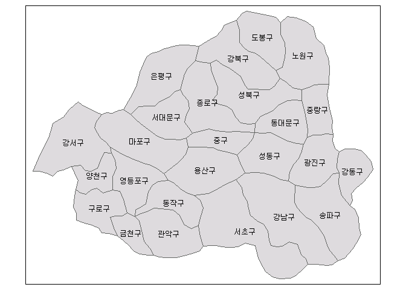

```r
qtm(seoul0, text = "name", text.size = 0.7)
```

# 자료 결합

## CSV 외부 화일 읽어오기

이제 구별 인구자료를 외부화일에서 불러들여 지도자료와 결합해 보자.

cvs 화일 **seoulpop-win.csv**에 저장된 인구자료를 데이터프레임 `pop`에 불러온다.

```r
pop <- read.table("seoulpop-win.csv", sep=",", header = TRUE)
```

데이터프레임 `pop` 의 내용은 다음과 같다.

```r
head(pop, n=5)
```

```
##   year   name   house      pop    popm    popf foreign density   area
## 1 1991   합계 3330317 10904527 5485353 5419174      NA   18014 605.33
## 2 1991 종로구   78169   236806  119127  117679      NA    9865  24.01
## 3 1991   중구   61495   184142   93312   90830      NA   18438   9.99
## 4 1991 용산구   96696   294341  147914  146427      NA   13460  21.87
## 5 1991 성동구  244272   789014  401375  387639      NA   23273  33.90
##   numhouse old65
## 1     3.27    NA
## 2     3.03    NA
## 3     2.99    NA
## 4     3.04    NA
## 5     3.23    NA
```

함수 `kable`을 이용하여 데이터프레임 `pop` 를 다음과 같이 나타낼 수 있다. 선택명령문 `font_size = 7` 는 문자의 크기를 조정한다.

```r
head(pop,n=30) %>%   kable() %>%   kable_styling(bootstrap_options = "striped", full_width = T, font_size = 7)
```

| year | name | house | pop | popm | popf | foreign | density | area | numhouse | old65 |
| --- | --- | --- | --- | --- | --- | --- | --- | --- | --- | --- |
| 1991 | 합계 | 3330317 | 10904527 | 5485353 | 5419174 | NA | 18014 | 605.33 | 3.27 | NA |
| 1991 | 종로구 | 78169 | 236806 | 119127 | 117679 | NA | 9865 | 24.01 | 3.03 | NA |
| 1991 | 중구 | 61495 | 184142 | 93312 | 90830 | NA | 18438 | 9.99 | 2.99 | NA |
| 1991 | 용산구 | 96696 | 294341 | 147914 | 146427 | NA | 13460 | 21.87 | 3.04 | NA |
| 1991 | 성동구 | 244272 | 789014 | 401375 | 387639 | NA | 23273 | 33.90 | 3.23 | NA |
| 1991 | 동대문구 | 149914 | 479776 | 242828 | 236948 | NA | 32477 | 14.77 | 3.20 | NA |
| 1991 | 중랑구 | 132908 | 450728 | 227075 | 223653 | NA | 24866 | 18.13 | 3.39 | NA |
| 1991 | 성북구 | 165634 | 542532 | 273509 | 269023 | NA | 22329 | 24.30 | 3.28 | NA |
| 1991 | 도봉구 | 221001 | 744880 | 373908 | 370972 | NA | 16721 | 44.55 | 3.37 | NA |
| 1991 | 노원구 | 161450 | 525500 | 263000 | 262500 | NA | 14758 | 35.61 | 3.25 | NA |
| 1991 | 은평구 | 147331 | 495530 | 245477 | 250053 | NA | 16699 | 29.67 | 3.36 | NA |
| 1991 | 서대문구 | 127136 | 392586 | 196281 | 196305 | NA | 22192 | 17.69 | 3.09 | NA |
| 1991 | 마포구 | 140847 | 442271 | 220887 | 221384 | NA | 18526 | 23.87 | 3.14 | NA |
| 1991 | 양천구 | 150598 | 508001 | 255927 | 252074 | NA | 28921 | 17.57 | 3.37 | NA |
| 1991 | 강서구 | 121174 | 408676 | 205712 | 202964 | NA | 9862 | 41.44 | 3.37 | NA |
| 1991 | 구로구 | 228191 | 747623 | 381977 | 365646 | NA | 22795 | 32.80 | 3.28 | NA |
| 1991 | 영등포구 | 141789 | 462359 | 233772 | 228587 | NA | 18922 | 24.44 | 3.26 | NA |
| 1991 | 동작구 | 133178 | 429173 | 216432 | 212741 | NA | 26206 | 16.38 | 3.22 | NA |
| 1991 | 관악구 | 177430 | 588638 | 298078 | 290560 | NA | 19855 | 29.65 | 3.32 | NA |
| 1991 | 서초구 | 125754 | 420783 | 208731 | 212052 | NA | 8852 | 47.53 | 3.35 | NA |
| 1991 | 강남구 | 150682 | 517218 | 258052 | 259166 | NA | 13271 | 38.97 | 3.43 | NA |
| 1991 | 송파구 | 207969 | 688121 | 342060 | 346061 | NA | 20371 | 33.78 | 3.31 | NA |
| 1991 | 강동구 | 166699 | 555829 | 279919 | 275910 | NA | 22744 | 24.44 | 3.33 | NA |
| 1992 | 합계 | 3383169 | 10969862 | 5519096 | 5450766 | 34632 | 18121 | 605.36 | 3.24 | 434348 |
| 1992 | 종로구 | 75752 | 227988 | 114648 | 113340 | 1748 | 9496 | 24.01 | 3.01 | 12096 |
| 1992 | 중구 | 59667 | 176836 | 89537 | 87299 | 2231 | 17701 | 9.99 | 2.96 | 8857 |
| 1992 | 용산구 | 96832 | 287124 | 144600 | 142524 | 6453 | 13135 | 21.86 | 2.97 | 13957 |
| 1992 | 성동구 | 244888 | 780526 | 397121 | 383405 | 2141 | 22991 | 33.95 | 3.19 | 28493 |
| 1992 | 동대문구 | 149094 | 470594 | 238385 | 232209 | 751 | 31862 | 14.77 | 3.16 | 19142 |
| 1992 | 중랑구 | 136876 | 458391 | 230937 | 227454 | 282 | 25284 | 18.13 | 3.35 | 15849 |

- `year` : 년도
- `name`: 한글행정구역 이름(구)
- `house`: 가구수
- `pop`: 인구수
- `popm`: 남자 인구수
- `popf`: 여자 인구수
- `foreign` : 외국인 인구수
- `density`: 인구밀도
- `area` : 면적
- `numhouse`: 가구당 평균 인구
- `old65`: 65세 이상 인구수

## 자료의 선택

이제 2017년의 구이름 `name`, 서울 구별 인구 `pop`, 65세 이상 인구 `old65`를 선택하여 데이터프레임 `values`에 저장한다. 이 경우 구의 이름이 **합계**인 자료는 제외한다.

```r
values <- pop %>% filter(year == 2017) %>% select(c("name","pop","old65"))
values <- values %>% filter( name != "합계" )
values
```

```
##        name    pop old65
## 1    종로구 164257 26182
## 2      중구 134593 21384
## 3    용산구 244444 36882
## 4    성동구 312711 41273
## 5    광진구 372298 43953
## 6  동대문구 366011 55718
## 7    중랑구 412780 59262
## 8    성북구 455407 66251
## 9    강북구 328002 56530
## 10   도봉구 346234 53488
## 11   노원구 558075 74243
## 12   은평구 491202 74559
## 13 서대문구 325028 49266
## 14   마포구 385783 49615
## 15   양천구 475018 55234
## 16   강서구 608255 76032
## 17   구로구 441559 58794
## 18   금천구 253491 34170
## 19 영등포구 402024 53981
## 20   동작구 408493 57255
## 21   관악구 520929 70046
## 22   서초구 445401 53205
## 23   강남구 561052 65060
## 24   송파구 671173 76582
## 25   강동구 440359 56161
```

함수 `kable`을 이용하여 2017년의 서울시 구별 인구를 표로 나타내 보자.

```r
values %>%   kable() %>%   kable_styling(bootstrap_options = "striped", full_width = F)
```

| name | pop | old65 |
| --- | --- | --- |
| 종로구 | 164257 | 26182 |
| 중구 | 134593 | 21384 |
| 용산구 | 244444 | 36882 |
| 성동구 | 312711 | 41273 |
| 광진구 | 372298 | 43953 |
| 동대문구 | 366011 | 55718 |
| 중랑구 | 412780 | 59262 |
| 성북구 | 455407 | 66251 |
| 강북구 | 328002 | 56530 |
| 도봉구 | 346234 | 53488 |
| 노원구 | 558075 | 74243 |
| 은평구 | 491202 | 74559 |
| 서대문구 | 325028 | 49266 |
| 마포구 | 385783 | 49615 |
| 양천구 | 475018 | 55234 |
| 강서구 | 608255 | 76032 |
| 구로구 | 441559 | 58794 |
| 금천구 | 253491 | 34170 |
| 영등포구 | 402024 | 53981 |
| 동작구 | 408493 | 57255 |
| 관악구 | 520929 | 70046 |
| 서초구 | 445401 | 53205 |
| 강남구 | 561052 | 65060 |
| 송파구 | 671173 | 76582 |
| 강동구 | 440359 | 56161 |

## 자료의 결합

이제 2017년의 서울 구별 인구가 저장된 데이터프레임 `values`를 지도자료에 결합하자. 함수 `left_join`은 두 개의 데이터프레임 `seoul0@data` 과 `values`를 결합하는데 결합의 기준이 되는 식별변수(ID variable)는 `name`을 이용하고 결합기준은 첫 번째 지정된 자료를 이용한다(`left`의 의미).

```r
seoul0@data <- left_join(seoul0@data,values, by = "name")
seoul0@data %>%   kable() %>%   kable_styling(bootstrap_options = "striped", full_width = F)
```

| code | engname | name | pop | old65 |
| --- | --- | --- | --- | --- |
| 1132000000 | Dobong | 도봉구 | 346234 | 53488 |
| 1123000000 | Dong-daemun | 동대문구 | 366011 | 55718 |
| 1159000000 | Dongjak | 동작구 | 408493 | 57255 |
| 1138000000 | Eun-pyeong | 은평구 | 491202 | 74559 |
| 1174000000 | Gandong | 강동구 | 440359 | 56161 |
| 1130500000 | Gangbuk | 강북구 | 328002 | 56530 |
| 1168000000 | Gangnam | 강남구 | 561052 | 65060 |
| 1150000000 | Gangseo | 강서구 | 608255 | 76032 |
| 1154500000 | Geum-cheon | 금천구 | 253491 | 34170 |
| 1153000000 | Guro | 구로구 | 441559 | 58794 |
| 1162000000 | Gwanak | 관악구 | 520929 | 70046 |
| 1121500000 | Gwang-jin | 광진구 | 372298 | 43953 |
| 1111000000 | Jongro | 종로구 | 164257 | 26182 |
| 1114000000 | Jung | 중구 | 134593 | 21384 |
| 1126000000 | Jungnang | 중랑구 | 412780 | 59262 |
| 1144000000 | Mapo | 마포구 | 385783 | 49615 |
| 1135000000 | Nowon | 노원구 | 558075 | 74243 |
| 1165000000 | Seocho | 서초구 | 445401 | 53205 |
| 1141000000 | Seodaemun | 서대문구 | 325028 | 49266 |
| 1129000000 | Seongbuk | 성북구 | 455407 | 66251 |
| 1120000000 | Seongdong | 성동구 | 312711 | 41273 |
| 1171000000 | Songpa | 송파구 | 671173 | 76582 |
| 1147000000 | Yangcheon | 양천구 | 475018 | 55234 |
| 1156000000 | Yeongdeungpo | 영등포구 | 402024 | 53981 |
| 1117000000 | Yongsan | 용산구 | 244444 | 36882 |

## 인구 지도 그리기

2017년 구별 인구를 함수 `qtm`을 이용하여 그림으로 그려보자. 인구의 규모는 색깔로 표시되며 (선택명령어 `fill ="pop"`) 범례(label)는 자동으로 출력된다. 선택명령어 `title`은 그림의 제목을 지정한다.

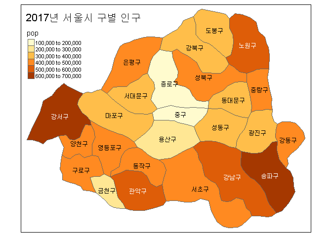

```r
qtm (seoul0,  fill ="pop", text = "name", title="2017년 서울시 구별 인구", text.size = 0.7)
```

# 여러 개의 지도의 생성

이제 시간에 따른 인구의 변화를 보여주는 여러 개의 지도를 작성하려고 한다.

## 시간별 인구 변화를 나타내는 지도

먼저 함수 `st_as_sf`를 이용하여 지도객체 `seoul0`에 있는 `data` 자료만을 추출하여 지도 데이터프레임(sf datframe) `seoul0data` 에 저장한다. 지도 데이터프레임(sf datframe)은 지도의 자료를 `SpatialPolygonsDataFrame` 형식보다 더 간략하게 저장하는 형식이다.

마지막으로 `select` 함수를 이용하여 두개의 변수 `name`과 `geometry`만 선택하여 저장한다.

```r
seoul0data <- st_as_sf(seoul0)
class(seoul0data)
```

```
## [1] "sf"         "data.frame"
```

```r
seoul0data <- seoul0data %>% select( name,  geometry)
```

새롭게 만든 데이터프레임 `seoul0data`에는 각 구의 위치정보가 변수 `geometry`에 저장되어 있다.

```r
head(seoul0data,n=2) %>%   kable() %>%   kable_styling(bootstrap_options = "striped", full_width = T, font_size = 10)
```

| name | geometry |
| --- | --- |
| 도봉구 | list(c(127.061706542969, 127.061614990234, 127.066680908203, 127.067504882812, 127.06689453125, 127.063781738281, 127.055908203125, 127.048889160156, 127.043518066406, 127.037292480469, 127.0313110351… |
| 동대문구 | list(c(127.093376159668, 127.088790893555, 127.080085754395, 127.070220947266, 127.05933380127, 127.049667358399, 127.041084289551, 127.031150817871, 127.03190612793, 127.037651062012, 127.04498291015… |

다음으로 인구자료 `pop`에서 1992, 1997, 2002, 2007, 2012, 2017년의 서울시 구별인구를 선택하여 데이터프레임 `pop1`에 저장한다. 이때 구이름이 **합계**인 경우를 제외한다.

함수 `filter`에서 선택명령어 `year %in% c(1992,1997,2002,2007,2012,2017)` 는 변수 `year`의 값이 벡터 `c(1992,1997,2002,2007,2012,2017)`에 있으면 선택한다.

```r
pop1 <- pop %>% select(year,name,pop, old65) %>%  filter(name != "합계", year %in% c(1992,1997,2002,2007,2012,2017))
```

이제 데이터프레임 `seoul0data`과 6개년도의 인구가 있는 데이터프레임 `pop1` 를 결합하여 `pop1_long`을 만들고 지도정보를 가지는 SF 데이터프레임으로 다시 변환해준다.

```r
pop1_long <- left_join(pop1, seoul0data, by = "name")
pop1_long <- st_as_sf(pop1_long)
```

```r
head(pop1_long,n=2) %>%   kable() %>%   kable_styling(bootstrap_options = "striped", full_width = T, font_size = 10)
```

| year | name | pop | old65 | geometry |
| --- | --- | --- | --- | --- |
| 1992 | 종로구 | 227988 | 12096 | list(c(127.031150817871, 127.00919342041, 127.000473022461, 126.985458374023, 126.977577209473, 126.965896606445, 126.95817565918, 126.953491210938, 126.948654174805, 126.950927734375, 126.95410919189… |
| 1992 | 중구 | 176836 | 8857 | list(c(127.031150817871, 127.028747558594, 127.023406982422, 127.015769958496, 127.010597229004, 127.001243591309, 126.988227844238, 126.982879638672, 126.967926025391, 126.959434509277, 126.953269958… |

다음은 1992년부터 2017년까지 5년 간격으로 구별 인구의 변화를 보여주는 그림이다.

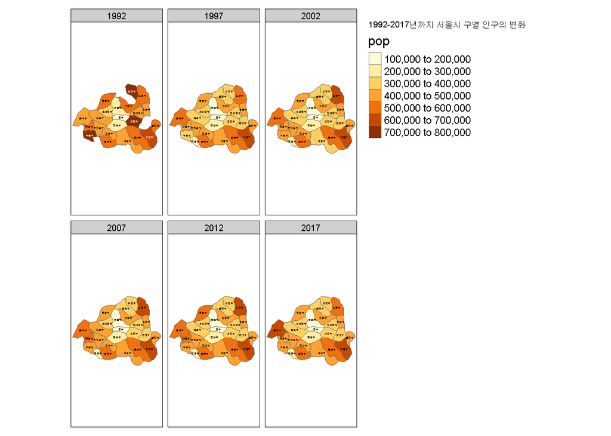

```r
tm_shape(pop1_long) +
tm_polygons("pop") +
tm_facets(by = "year") +
tm_text(text = "name",size=0.3)+
tm_layout(title = "1992-2017년까지 서울시 구별 인구의 변화")
```

다음 1992년부터 2017년까지 5년 간격 구별로 65세 이상 노인 인구의 변화를 보여주는 그림이다.

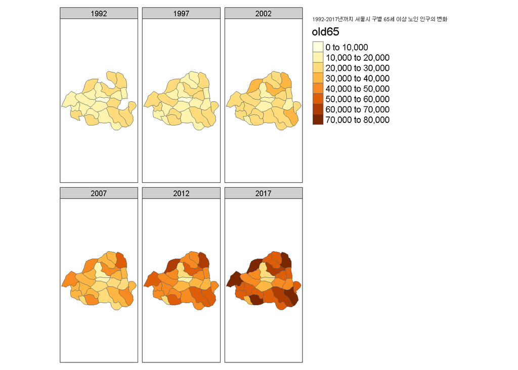

```r
tm_shape(pop1_long) +
tm_polygons("old65") +
tm_facets(by = "year") +
tm_layout(title = "1992-2017년까지 서울시 구별 65세 이상 노인 인구의 변화")
```

이제 새로운 변수 `old65ratio`인 노인 인구의 비율(벡분율)을 계산하여 그 값을 지도로 그리는 방법을 살펴보자

먼저 새로운 변수를 만드는 함수 `mutate`를 사용하여 노인인구 `old65`를 전체 인구 `pop`로 나누어 100을 곱하여 백분율을 계산한다. 이때 `round`함수를 이용하여 소수 2자리로 만들어 (`digit=2`) 새로운 변수 `old65ratio`에 저장한다.

```r
pop1_long <- pop1_long %>% mutate(old65ratio = round(old65/pop*100, digit=2))
pop1_long
```

```
## Simple feature collection with 147 features and 5 fields
## geometry type:  POLYGON
## dimension:      XY
## bbox:           xmin: 126.7699 ymin: 37.41528 xmax: 127.1709 ymax: 37.66492
## epsg (SRID):    4326
## proj4string:    +proj=longlat +datum=WGS84 +no_defs
## First 10 features:
##    year     name    pop old65 old65ratio                       geometry
## 1  1992   종로구 227988 12096       5.31 POLYGON ((127.0312 37.55182...
## 2  1992     중구 176836  8857       5.01 POLYGON ((127.0312 37.55182...
## 3  1992   용산구 287124 13957       4.86 POLYGON ((126.9242 37.51343...
## 4  1992   성동구 780526 28493       3.65 POLYGON ((127.0709 37.50633...
## 5  1992 동대문구 470594 19142       4.07 POLYGON ((127.0934 37.54733...
## 6  1992   중랑구 458391 15849       3.46 POLYGON ((127.0934 37.54733...
## 7  1992   성북구 527296 23020       4.37 POLYGON ((127.0319 37.56025...
## 8  1992   도봉구 766799 29689       3.87 POLYGON ((127.0617 37.65409...
## 9  1992   노원구 571833 24345       4.26 POLYGON ((127.1186 37.59677...
## 10 1992   은평구 507551 20672       4.07 POLYGON ((126.9437 37.59166...
```

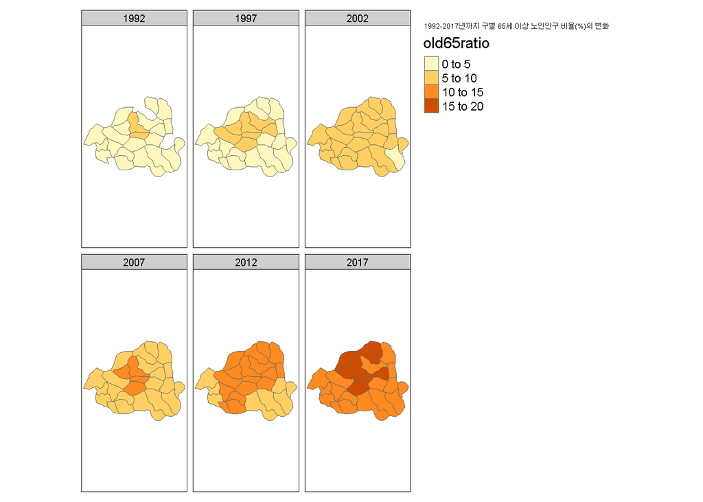

```r
tm_shape(pop1_long) +
tm_polygons("old65ratio") +
tm_facets(by = "year")  +
tm_layout(title = "1992-2017년까지 구별 65세 이상 노인인구 비율(%)의 변화")
```